# Projet STA203

## Introduction

L’objectif de ce projet est d’arriver à s’affranchir des analyses chimiques côuteuses pour pouvoir déterminer la teneur en en sucre. Pour cela, nous construirons un modèle d’apprentissage statistique en nous basant sur un dataset contenant des mesures de spectrométrie infrarouge contenu dans le jeu de données .

## Analyse Exploratoire

Pour nous familiariser avec le jeu de donnée on va faire une analyse exploratoire du dataset.

```
[1]  40 700
```

On a donc un dataset avec 700 variables qui représentent les fréquences auxquelles on mesure l’absorbance et 40 individus.

|  | X1 | X2 | X3 | X4 | X5 | X6 | X7 | X8 | X9 | X10 | X11 | X12 | X13 | X14 | X15 | X16 | X17 | X18 | X19 | X20 | X21 | X22 | X23 | X24 | X25 | X26 | X27 | X28 | X29 | … |
| --- | --- | --- | --- | --- | --- | --- | --- | --- | --- | --- | --- | --- | --- | --- | --- | --- | --- | --- | --- | --- | --- | --- | --- | --- | --- | --- | --- | --- | --- | --- |
| 1 | 0.249846 | 0.249745 | 0.249441 | 0.249036 | 0.248885 | 0.248986 | 0.249036 | 0.249239 | 0.249846 | 0.250858 | 0.251668 | 0.252832 | 0.254148 | 0.256071 | 0.258500 | 0.261638 | 0.265231 | 0.269482 | 0.273986 | 0.279249 | 0.284967 | 0.291243 | 0.297872 | 0.304805 | 0.311941 | 0.319329 | 0.326769 | 0.334309 | 0.341647 | … |
| 2 | 0.256096 | 0.256096 | 0.256353 | 0.256559 | 0.256868 | 0.256868 | 0.256662 | 0.256662 | 0.256920 | 0.257847 | 0.259237 | 0.260679 | 0.262379 | 0.264490 | 0.266704 | 0.269846 | 0.273502 | 0.277776 | 0.282462 | 0.287921 | 0.293792 | 0.300280 | 0.307130 | 0.314133 | 0.321652 | 0.329376 | 0.337204 | 0.344929 | 0.352396 | … |
| 3 | 0.274770 | 0.274720 | 0.274819 | 0.274770 | 0.274819 | 0.274620 | 0.274819 | 0.274969 | 0.275665 | 0.276511 | 0.278004 | 0.279447 | 0.281089 | 0.283477 | 0.286115 | 0.289548 | 0.293728 | 0.298803 | 0.304476 | 0.310347 | 0.316866 | 0.323832 | 0.331246 | 0.339008 | 0.347020 | 0.355479 | 0.363988 | 0.372397 | 0.380458 | … |
| 4 | 0.243735 | 0.243735 | 0.243782 | 0.243688 | 0.243453 | 0.243265 | 0.243218 | 0.243312 | 0.243876 | 0.244816 | 0.245897 | 0.247448 | 0.248811 | 0.250879 | 0.253370 | 0.256096 | 0.259950 | 0.264461 | 0.269255 | 0.274519 | 0.280206 | 0.286269 | 0.292802 | 0.299569 | 0.306666 | 0.313951 | 0.321424 | 0.328944 | 0.336463 | … |
| 5 | 0.243405 | 0.243261 | 0.243261 | 0.243357 | 0.243070 | 0.242927 | 0.243118 | 0.243501 | 0.244074 | 0.245079 | 0.246465 | 0.248091 | 0.249622 | 0.251439 | 0.253830 | 0.257034 | 0.260716 | 0.265211 | 0.270280 | 0.275875 | 0.281852 | 0.288404 | 0.295194 | 0.302367 | 0.309827 | 0.317574 | 0.325273 | 0.332972 | 0.340337 | … |
| 6 | 0.253504 | 0.253356 | 0.253356 | 0.253504 | 0.253701 | 0.253553 | 0.253652 | 0.253948 | 0.254392 | 0.255034 | 0.256318 | 0.257503 | 0.259528 | 0.261651 | 0.264070 | 0.267231 | 0.271082 | 0.275575 | 0.280464 | 0.285747 | 0.291870 | 0.298536 | 0.305646 | 0.312954 | 0.320657 | 0.328360 | 0.336112 | 0.343469 | 0.351123 | … |

|  | sucres |
| --- | --- |
| 1 | 13.32 |
| 2 | 15.65 |
| 3 | 19.06 |
| 4 | 19.40 |
| 5 | 15.35 |
| 6 | 12.31 |

|  | X1 | X2 | X3 | X4 | X5 | X6 | X7 | X8 | X9 | X10 | X11 | X12 | X13 | X14 | X15 | X16 | X17 | X18 | X19 | X20 | X21 | X22 | X23 | X24 | X25 | X26 | X27 | X28 | X29 | … |
| --- | --- | --- | --- | --- | --- | --- | --- | --- | --- | --- | --- | --- | --- | --- | --- | --- | --- | --- | --- | --- | --- | --- | --- | --- | --- | --- | --- | --- | --- | --- |
| 1 | 0.259748 | 0.259482 | 0.259535 | 0.259270 | 0.259376 | 0.259270 | 0.259642 | 0.259801 | 0.260172 | 0.260863 | 0.261977 | 0.263198 | 0.264685 | 0.266702 | 0.268878 | 0.271427 | 0.274771 | 0.278805 | 0.283212 | 0.288149 | 0.293563 | 0.299668 | 0.306038 | 0.312780 | 0.319947 | 0.327432 | 0.335182 | 0.342880 | 0.350683 | … |
| 2 | 0.267625 | 0.267320 | 0.267117 | 0.266864 | 0.266965 | 0.267016 | 0.267422 | 0.267878 | 0.268538 | 0.269452 | 0.270720 | 0.271989 | 0.273613 | 0.275947 | 0.278636 | 0.281833 | 0.285588 | 0.290104 | 0.295280 | 0.300710 | 0.307104 | 0.313954 | 0.321211 | 0.328771 | 0.336535 | 0.344451 | 0.352621 | 0.360842 | 0.369113 | … |
| 3 | 0.251753 | 0.251654 | 0.251851 | 0.251900 | 0.252047 | 0.252342 | 0.252735 | 0.253177 | 0.254012 | 0.254798 | 0.256124 | 0.258138 | 0.260103 | 0.262707 | 0.265507 | 0.268602 | 0.272384 | 0.276854 | 0.281865 | 0.287514 | 0.293801 | 0.300286 | 0.307114 | 0.314285 | 0.321801 | 0.329612 | 0.337766 | 0.345969 | 0.354075 | … |
| 4 | 0.278077 | 0.277877 | 0.277827 | 0.278077 | 0.277777 | 0.278027 | 0.278177 | 0.278427 | 0.278727 | 0.279328 | 0.280178 | 0.281628 | 0.283279 | 0.285229 | 0.287630 | 0.290681 | 0.293882 | 0.297983 | 0.302734 | 0.307886 | 0.313937 | 0.320389 | 0.327141 | 0.334243 | 0.341645 | 0.349297 | 0.357299 | 0.365352 | 0.373304 | … |
| 5 | 0.288900 | 0.288484 | 0.288328 | 0.288328 | 0.288328 | 0.288796 | 0.289316 | 0.289783 | 0.290095 | 0.290823 | 0.291655 | 0.292746 | 0.294566 | 0.296541 | 0.298984 | 0.301895 | 0.305585 | 0.309691 | 0.314526 | 0.320035 | 0.326013 | 0.332718 | 0.339735 | 0.346961 | 0.354653 | 0.362554 | 0.370611 | 0.378564 | 0.386673 | … |
| 6 | 0.285423 | 0.284891 | 0.284625 | 0.284625 | 0.284678 | 0.284731 | 0.284785 | 0.284944 | 0.285370 | 0.286115 | 0.287179 | 0.288509 | 0.290319 | 0.292553 | 0.295108 | 0.298247 | 0.302025 | 0.306654 | 0.311763 | 0.317563 | 0.324054 | 0.330918 | 0.338102 | 0.345711 | 0.353693 | 0.361940 | 0.370507 | 0.379128 | 0.387694 | … |

|  | sucres |
| --- | --- |
| 1 | 13.32 |
| 2 | 15.65 |
| 3 | 19.06 |
| 4 | 19.40 |
| 5 | 15.35 |
| 6 | 12.31 |

On va tracer les boxplots des variables explicatives pour étudier les variabilités.

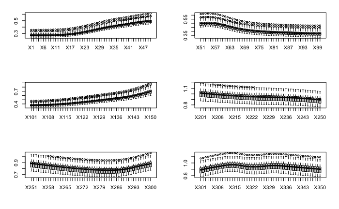

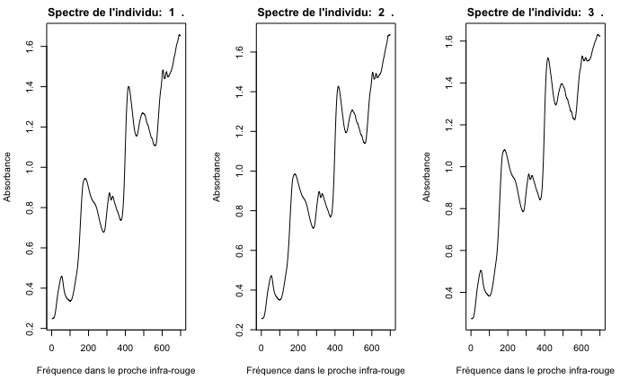

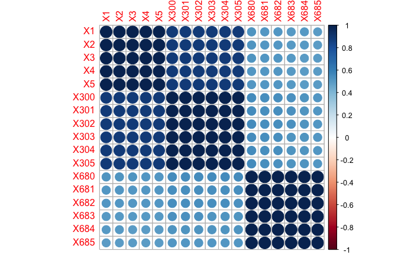

On remarque bien que notre hypothèse de continuité est vérifiée car la corrélation entre les fréquences proches est proche de 1 alors que pour des fréquences plus éloignées la corrélation est plus faible. On effectue maintenant une ACP sur le dataset.

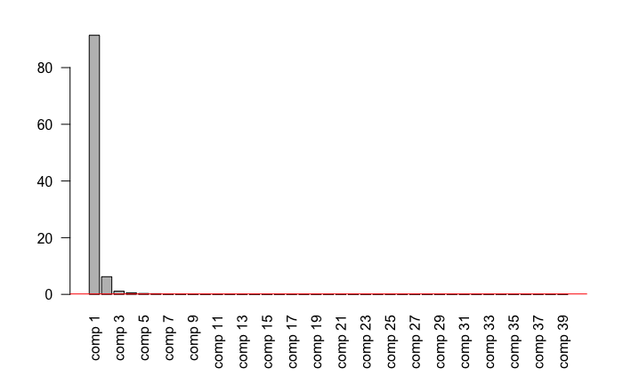

La PCA se fait que sur 39 variable ceci est due au fait que la matrice $X'X$ n’est pas injective, on se trouve bien dans le cadre discuté en première partie. La représentation des nuages de points sur les 6 axes principaux donne:

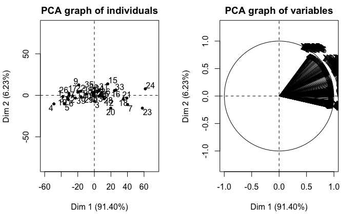

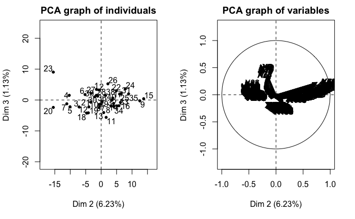

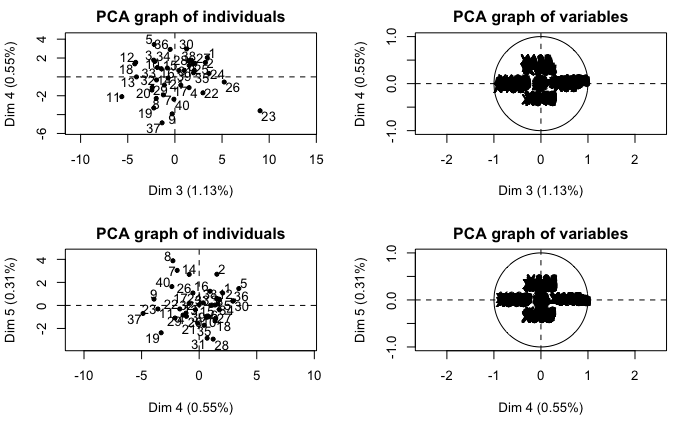

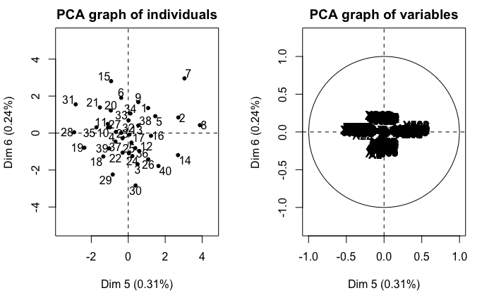

On vérifie que la fonction avec xtrain:

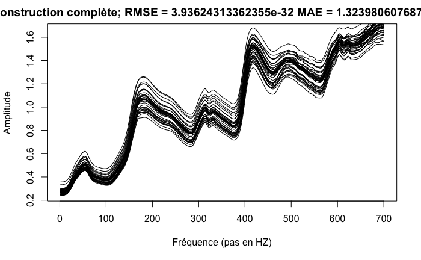

On a bien les même spectres ( les erreurs quadratiques moyennes et en valeur absolue sont raisonnables ) la reconstruction est donc bonne. On fait la reconstruction pour un nombre d’axes donné:

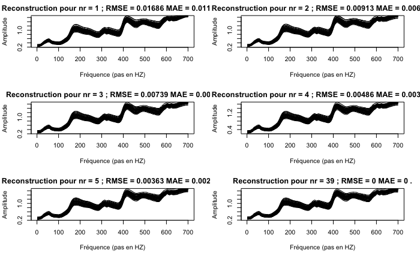

## Régression pénalisée

### Question 3.1

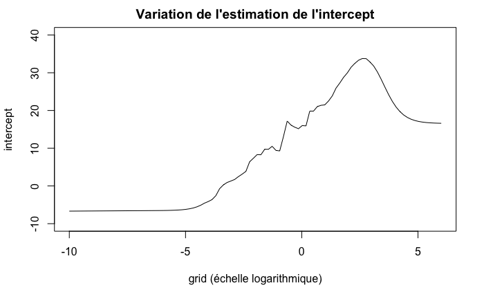

L’estimateur de l’intercept n’est pas pénalisé et dépend grandement de la valeur des autres paramètres estimés qui eux sont étroitement liés à la valeur du paramètre de pénalisation. Quand le paramètre de pénalisation tend vers zéro on voit bien qu’on converge vers la limite en zéro du modèle. On trouve bien le comportement prédit par la théorie.

```
         [,1]
[1,] 16.60476
[1] 16.60476
```

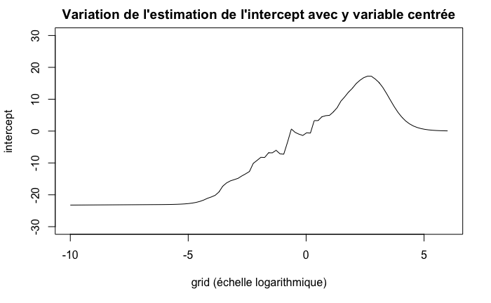

Lorsque l’on centre on translate simplement la courbe obtenue avec le x choisi ( ou xtrain centré) vers le bas de la moyenne empirique de .

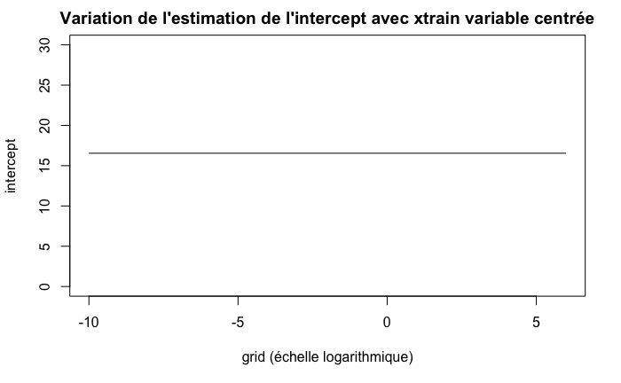

Dans le cas ou est centrée. On a l’intercept qui est égal à la moyenne empirique de ce qui est normal.

Dans le cas où les deux sont centrées on a:

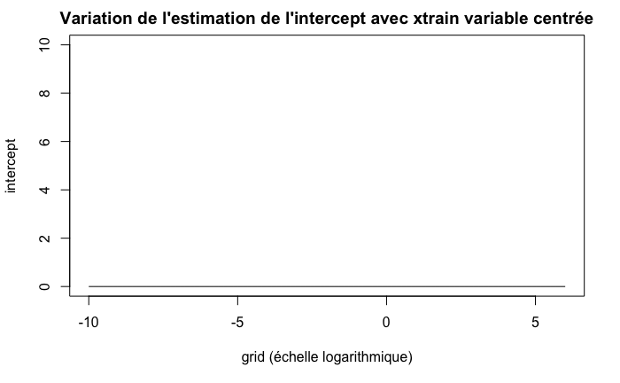

On retrouve bien un intercept nul comme attendu. Dans le cas où les variables sont centrées réduites on a:

```
[1] 700   1
       sucres
[1,] 15.01621
```